# Etape 5 : Visualisations avec données DataFrame_Complet.csv

# Validation du modèle Random Forest

```python
from sklearn.model_selection import cross_val_score

# Pour la classification
scores = cross_val_score(clf, X, y, cv=5, scoring='accuracy')
print(f"Accuracy pour chaque fold : {scores}")
print(f"Accuracy moyenne (Cross-Validation) : {scores.mean():.2f} (+/- {scores.std():.2f})")
```

```
Accuracy pour chaque fold : [0.92478226 1.         1.         0.99841647 0.72662441]
Accuracy moyenne (Cross-Validation) : 0.93 (+/- 0.11)
```

# Interprétation - accuracy Cross val

- Une Accuracy moyenne de 0.93 (93%) est très élevée et indique que, en moyenne, notre modèle Random Forest est capable de faire des prédictions correctes dans 93% des cas sur des données invisibles lors de la validation croisée.
- L'écart type de 0.11 (11%) est relativement élevé, surtout si l'on regarde les scores individuels des folds :
  - Trois folds ont des performances quasi parfaites (1.0, 1.0, 0.998).
  - Un fold est très bon (0.924).
  - Cependant, un fold a une performance significativement plus faible (0.726).
- Le fait qu'un des folds ait une accuracy de 0.726 mérite une attention particulière. Cela signifie que pour ce segment spécifique de vos données, le modèle a eu beaucoup plus de mal à faire des prédictions précises.

## Apprentissage non supervisé

```python
print("\n--- Début de l'apprentissage non supervisé ---")

features_for_clustering = ml_df[['CVSS_score', 'EPSS_score', 'EPSS_percentile']]

scaler = StandardScaler()
X_scaled = scaler.fit_transform(features_for_clustering)

# Application de K-Means pour trouver 3 clusters
kmeans = KMeans(n_clusters=3, random_state=42, n_init=10)
ml_df['cluster'] = kmeans.fit_predict(X_scaled)

cluster_centers = scaler.inverse_transform(kmeans.cluster_centers_)
centers_df = pd.DataFrame(cluster_centers, columns=['CVSS_score', 'EPSS_score', 'EPSS_percentile'])
print("\nCaractéristiques moyennes des clusters :")
print(centers_df)
```

```
--- Début de l'apprentissage non supervisé ---

Caractéristiques moyennes des clusters :
   CVSS_score  EPSS_score  EPSS_percentile
0    8.731111    0.621832         0.974871
1    7.899966    0.001377         0.193598
2    5.453697    0.001527         0.214827
```

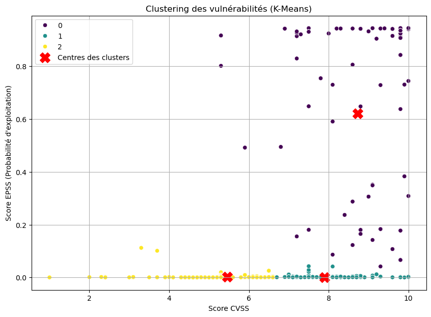

```
Score Silhouette : 0.554
```

```python
from sklearn.metrics import silhouette_score

plt.figure(figsize=(10, 7))
sns.scatterplot(data=ml_df, x='CVSS_score', y='EPSS_score', hue='cluster', palette='viridis', legend='full')
plt.scatter(centers_df['CVSS_score'], centers_df['EPSS_score'], s=200, c='red', marker='X', label='Centres des clusters')
plt.title('Clustering des vulnérabilités (K-Means)')
plt.xlabel('Score CVSS')
plt.ylabel('Score EPSS (Probabilité d\'exploitation)')
plt.legend()
plt.grid(True)
plt.show()

# Calculate Silhouette Score
silhouette_avg = silhouette_score(X_scaled, ml_df['cluster'])
print(f"\nScore Silhouette : {silhouette_avg:.3f}")
```